# Predict Bike Sharing Demand with AutoGluon Template

## Project: Predict Bike Sharing Demand with AutoGluon

This notebook is a template with each step that you need to complete for the project.

Please fill in your code where there are explicit `?` markers in the notebook. You are welcome to add more cells and code as you see fit.

Once you have completed all the code implementations, please export your notebook as a HTML file so the reviews can view your code. Make sure you have all outputs correctly outputted.

`File-> Export Notebook As... -> Export Notebook as HTML`

There is a writeup to complete as well after all code implememtation is done. Please answer all questions and attach the necessary tables and charts. You can complete the writeup in either markdown or PDF.

Completing the code template and writeup template will cover all of the rubric points for this project.

The rubric contains "Stand Out Suggestions" for enhancing the project beyond the minimum requirements. The stand out suggestions are optional. If you decide to pursue the "stand out suggestions", you can include the code in this notebook and also discuss the results in the writeup file.

## Step 2: Download the Kaggle dataset using the kaggle python library

### Open up Sagemaker Studio and use starter template

1. Notebook should be using a `ml.t3.medium` instance (2 vCPU + 4 GiB)
2. Notebook should be using kernal: `Python 3 (MXNet 1.8 Python 3.7 CPU Optimized)`

### Install packages

```python
!pip install ray
```

```python
!pip install "mxnet<2.0.0"
```

[output not shown]

[output not shown]

[output not shown]

[output cut: 92 more lines]

[output not shown]

[output not shown]

```python
!pip install autogluon
```

[output not shown]

[output cut: 45 more lines]

[output not shown]

```python
# Exporting packages for my own use on other machines
!pip freeze>aws_mxnet_requirements.txt
```

```python
!pip install kaggle
```

### Setup Kaggle API Key

```python
# # create the .kaggle directory and an empty kaggle.json file
# !mkdir -p /root/.kaggle
# !touch /root/.kaggle/kaggle.json
# !chmod 600 /root/.kaggle/kaggle.json
```

```python
# # Fill in your user name and key from creating the kaggle account and API token file
# import json

# # TODO: delete kaggle keys below before submitting file
# kaggle_username = "XXX"
# kaggle_key = "YYYY"

# # Save API token the kaggle.json file
# with open("/root/.kaggle/kaggle.json", "w") as f:
#     f.write(json.dumps({"username": kaggle_username, "key": kaggle_key}))
```

```python
## JSON from Kaggle downloaded and kept in proper place for linking Kaggle account to local environment
```

### Download and explore dataset

### Go to the bike sharing demand competition and agree to the terms

```python
# Installing kaggle command
#!pip install kaggle

# Download the dataset, it will be in a .zip file so you'll need to unzip it as well.
!kaggle competitions download -c bike-sharing-demand
# If you already downloaded it you can use the -o command to overwrite the file
import zipfile
import os

# Extract the downloaded zip file
with zipfile.ZipFile('bike-sharing-demand.zip', 'r') as zip_ref:
    zip_ref.extractall('./data/')
```

```
bike-sharing-demand.zip: Skipping, found more recently modified local copy (use --force to force download)
```

```python
import pandas as pd
import numpy as np
from autogluon.tabular import TabularPredictor
import autogluon.core as ag
from ray import tune

from sklearn.model_selection import train_test_split

import matplotlib.pyplot as plt

%matplotlib inline
```

```python
import autogluon.common as atc
```

```python
# # vWill be used to prefix kaggle's submissions
# notebook_version=2

# # Configure if a model should be submitted to kaggle
# submit_to_kaggle=True
```

```python
# Create the train dataset in pandas by reading the csv
# Set the parsing of the datetime column so you can use some of the `dt` features in pandas later
train = pd.read_csv("train.csv")
train["datetime"] = pd.to_datetime(train["datetime"])
train.head()
```

|  | datetime | season | holiday | workingday | weather | temp | atemp | humidity | windspeed | casual | registered | count |
| --- | --- | --- | --- | --- | --- | --- | --- | --- | --- | --- | --- | --- |
| 0 | 2011-01-01 00:00:00 | 1 | 0 | 0 | 1 | 9.84 | 14.395 | 81 | 0.0 | 3 | 13 | 16 |
| 1 | 2011-01-01 01:00:00 | 1 | 0 | 0 | 1 | 9.02 | 13.635 | 80 | 0.0 | 8 | 32 | 40 |
| 2 | 2011-01-01 02:00:00 | 1 | 0 | 0 | 1 | 9.02 | 13.635 | 80 | 0.0 | 5 | 27 | 32 |
| 3 | 2011-01-01 03:00:00 | 1 | 0 | 0 | 1 | 9.84 | 14.395 | 75 | 0.0 | 3 | 10 | 13 |
| 4 | 2011-01-01 04:00:00 | 1 | 0 | 0 | 1 | 9.84 | 14.395 | 75 | 0.0 | 0 | 1 | 1 |

```python
train.info()
```

```
<class 'pandas.core.frame.DataFrame'>
RangeIndex: 10886 entries, 0 to 10885
Data columns (total 12 columns):
 #   Column      Non-Null Count  Dtype
---  ------      --------------  -----
 0   datetime    10886 non-null  datetime64[ns]
 1   season      10886 non-null  int64
 2   holiday     10886 non-null  int64
 3   workingday  10886 non-null  int64
 4   weather     10886 non-null  int64
 5   temp        10886 non-null  float64
 6   atemp       10886 non-null  float64
 7   humidity    10886 non-null  int64
 8   windspeed   10886 non-null  float64
 9   casual      10886 non-null  int64
 10  registered  10886 non-null  int64
 11  count       10886 non-null  int64
dtypes: datetime64[ns](1), float64(3), int64(8)
memory usage: 1020.7 KB
```

```python
# Simple output of the train dataset to view some of the min/max/varition of the dataset features.
train.describe().T
```

|  | count | mean | min | 25% | 50% | 75% | max | std |
| --- | --- | --- | --- | --- | --- | --- | --- | --- |
| datetime | 10886 | 2011-12-27 05:56:22.399411968 | 2011-01-01 00:00:00 | 2011-07-02 07:15:00 | 2012-01-01 20:30:00 | 2012-07-01 12:45:00 | 2012-12-19 23:00:00 | NaN |
| season | 10886.0 | 2.506614 | 1.0 | 2.0 | 3.0 | 4.0 | 4.0 | 1.116174 |
| holiday | 10886.0 | 0.028569 | 0.0 | 0.0 | 0.0 | 0.0 | 1.0 | 0.166599 |
| workingday | 10886.0 | 0.680875 | 0.0 | 0.0 | 1.0 | 1.0 | 1.0 | 0.466159 |
| weather | 10886.0 | 1.418427 | 1.0 | 1.0 | 1.0 | 2.0 | 4.0 | 0.633839 |
| temp | 10886.0 | 20.23086 | 0.82 | 13.94 | 20.5 | 26.24 | 41.0 | 7.79159 |
| atemp | 10886.0 | 23.655084 | 0.76 | 16.665 | 24.24 | 31.06 | 45.455 | 8.474601 |
| humidity | 10886.0 | 61.88646 | 0.0 | 47.0 | 62.0 | 77.0 | 100.0 | 19.245033 |
| windspeed | 10886.0 | 12.799395 | 0.0 | 7.0015 | 12.998 | 16.9979 | 56.9969 | 8.164537 |
| casual | 10886.0 | 36.021955 | 0.0 | 4.0 | 17.0 | 49.0 | 367.0 | 49.960477 |
| registered | 10886.0 | 155.552177 | 0.0 | 36.0 | 118.0 | 222.0 | 886.0 | 151.039033 |
| count | 10886.0 | 191.574132 | 1.0 | 42.0 | 145.0 | 284.0 | 977.0 | 181.144454 |

```python
# Create the test pandas dataframe in pandas by reading the csv, remember to parse the datetime!
test = pd.read_csv("test.csv")
test["datetime"] = pd.to_datetime(test["datetime"])
test.head()
```

|  | datetime | season | holiday | workingday | weather | temp | atemp | humidity | windspeed |
| --- | --- | --- | --- | --- | --- | --- | --- | --- | --- |
| 0 | 2011-01-20 00:00:00 | 1 | 0 | 1 | 1 | 10.66 | 11.365 | 56 | 26.0027 |
| 1 | 2011-01-20 01:00:00 | 1 | 0 | 1 | 1 | 10.66 | 13.635 | 56 | 0.0000 |
| 2 | 2011-01-20 02:00:00 | 1 | 0 | 1 | 1 | 10.66 | 13.635 | 56 | 0.0000 |
| 3 | 2011-01-20 03:00:00 | 1 | 0 | 1 | 1 | 10.66 | 12.880 | 56 | 11.0014 |
| 4 | 2011-01-20 04:00:00 | 1 | 0 | 1 | 1 | 10.66 | 12.880 | 56 | 11.0014 |

```python
test.info()
```

```
<class 'pandas.core.frame.DataFrame'>
RangeIndex: 6493 entries, 0 to 6492
Data columns (total 9 columns):
 #   Column      Non-Null Count  Dtype
---  ------      --------------  -----
 0   datetime    6493 non-null   datetime64[ns]
 1   season      6493 non-null   int64
 2   holiday     6493 non-null   int64
 3   workingday  6493 non-null   int64
 4   weather     6493 non-null   int64
 5   temp        6493 non-null   float64
 6   atemp       6493 non-null   float64
 7   humidity    6493 non-null   int64
 8   windspeed   6493 non-null   float64
dtypes: datetime64[ns](1), float64(3), int64(5)
memory usage: 456.7 KB
```

```python
# Same thing as train and test dataset
submission = pd.read_csv("sampleSubmission.csv")
submission.head()
```

|  | datetime | count |
| --- | --- | --- |
| 0 | 2011-01-20 00:00:00 | 0 |
| 1 | 2011-01-20 01:00:00 | 0 |
| 2 | 2011-01-20 02:00:00 | 0 |
| 3 | 2011-01-20 03:00:00 | 0 |
| 4 | 2011-01-20 04:00:00 | 0 |

## Step 3: Train a model using AutoGluon’s Tabular Prediction

Requirements:

- We are predicting `count`, so it is the label we are setting.
- Ignore `casual` and `registered` columns as they are also not present in the test dataset.
- Use the `root_mean_squared_error` as the metric to use for evaluation.
- Set a time limit of 10 minutes (600 seconds).
- Use the preset `best_quality` to focus on creating the best model.

```python
# Creating my own test set
train_df, test_df = train_test_split(train, test_size=.1, random_state=42)

train_df.shape, test_df.shape
```

```
((9797, 12), (1089, 12))
```

```python
predictor = TabularPredictor(label="count",
                             problem_type="regression",
                             eval_metric="root_mean_squared_error",
                             verbosity=1,
                             learner_kwargs={
                                 "ignored_columns": ["casual", "registered"] # column to ignore for training/prediction
                             }) \
                             .fit(
    train_data=train_df,
    time_limit=600, #seconds
    presets="best_quality"
)
```

[output not shown]

### Review AutoGluon's training run with ranking of models that did the best.

```python
predictor.fit_summary()
```

```
*** Summary of fit() ***
Estimated performance of each model:
                     model   score_val              eval_metric  pred_time_val    fit_time  pred_time_val_marginal  fit_time_marginal  stack_level  can_infer  fit_order
0      WeightedEnsemble_L3  -62.602298  root_mean_squared_error       5.279932  347.148842                0.000000           0.027879            3       True         23
1   NeuralNetFastAI_BAG_L2  -64.619398  root_mean_squared_error       4.491486  277.401345                0.168306          13.572336            2       True         19
2   RandomForestMSE_BAG_L2  -65.986007  root_mean_squared_error       4.736574  270.000099                0.413394           6.171090            2       True         16
3     LightGBMLarge_BAG_L2  -66.227866  root_mean_squared_error       4.581206  270.210690                0.258026           6.381681            2       True         22
4          LightGBM_BAG_L2  -66.419418  root_mean_squared_error       4.492168  266.879217                0.168988           3.050208            2       True         15
5     ExtraTreesMSE_BAG_L2  -66.483062  root_mean_squared_error       4.711233  265.607427                0.388054           1.778418            2       True         18
6    NeuralNetTorch_BAG_L2  -66.665469  root_mean_squared_error       4.440205  320.995857                0.117025          57.166847            2       True         21
7           XGBoost_BAG_L2  -66.968880  root_mean_squared_error       4.400293  267.442829                0.077114           3.613820            2       True         20
8          CatBoost_BAG_L2  -67.411516  root_mean_squared_error       4.336383  289.881672                0.013203          26.052663            2       True         17
9        LightGBMXT_BAG_L2  -70.958564  root_mean_squared_error       5.286383  270.341385                0.963203           6.512375            2       True         14
10     WeightedEnsemble_L2  -89.493118  root_mean_squared_error       0.034455    0.039144                0.000000           0.016944            2       True         13
11   KNeighborsDist_BAG_L1  -89.493118  root_mean_squared_error       0.034455    0.022200                0.034455           0.022200            1       True          2
12   KNeighborsUnif_BAG_L1 -106.912937  root_mean_squared_error       0.030926    0.036065                0.030926           0.036065            1       True          1
13  RandomForestMSE_BAG_L1 -119.155939  root_mean_squared_error       0.353565    1.695431                0.353565           1.695431            1       True          5
14    ExtraTreesMSE_BAG_L1 -125.652359  root_mean_squared_error       0.350214    0.941593                0.350214           0.941593            1       True          7
15    LightGBMLarge_BAG_L1 -131.790133  root_mean_squared_error       0.295668    3.204253                0.295668           3.204253            1       True         11
16         LightGBM_BAG_L1 -132.113929  root_mean_squared_error       0.465974    3.721049                0.465974           3.721049            1       True          4
17         CatBoost_BAG_L1 -132.226324  root_mean_squared_error       0.043786   53.016459                0.043786          53.016459            1       True          6
18    CatBoost_r177_BAG_L1 -132.283391  root_mean_squared_error       0.000000   21.810345                0.000000          21.810345            1       True         12
19       LightGBMXT_BAG_L1 -133.020641  root_mean_squared_error       2.322688   11.159756                2.322688          11.159756            1       True          3
20          XGBoost_BAG_L1 -133.172478  root_mean_squared_error       0.142247    3.442616                0.142247           3.442616            1       True          9
21   NeuralNetTorch_BAG_L1 -136.369952  root_mean_squared_error       0.092688  150.053629                0.092688         150.053629            1       True         10
22  NeuralNetFastAI_BAG_L1 -136.815752  root_mean_squared_error       0.190967   14.725612                0.190967          14.725612            1       True          8
Number of models trained: 23
Types of models trained:
{'StackerEnsembleModel_KNN', 'StackerEnsembleModel_TabularNeuralNetTorch', 'StackerEnsembleModel_XGBoost', 'StackerEnsembleModel_CatBoost', 'StackerEnsembleModel_LGB', 'StackerEnsembleModel_RF', 'StackerEnsembleModel_NNFastAiTabular', 'StackerEnsembleModel_XT', 'WeightedEnsembleModel'}
Bagging used: True  (with 8 folds)
Multi-layer stack-ensembling used: True  (with 3 levels)
Feature Metadata (Processed):
(raw dtype, special dtypes):
('float', [])                : 3 | ['temp', 'atemp', 'windspeed']
('int', [])                  : 3 | ['season', 'weather', 'humidity']
('int', ['bool'])            : 2 | ['holiday', 'workingday']
('int', ['datetime_as_int']) : 5 | ['datetime', 'datetime.year', 'datetime.month', 'datetime.day', 'datetime.dayofweek']
*** End of fit() summary ***
```

[output not shown]

[output cut: 327 more lines]

[output not shown]

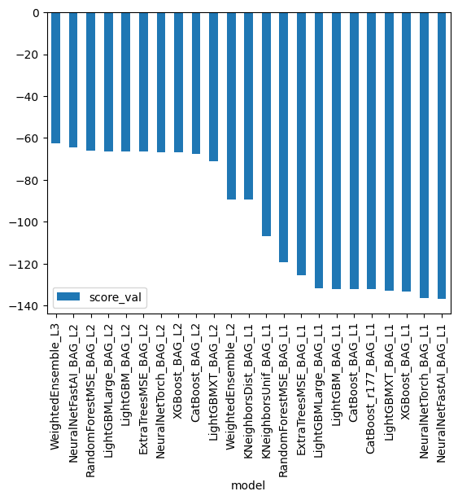

```python
# plt.figure(figsize=[10,8]);
predictor.leaderboard(silent=True).plot(kind="bar", x="model", y="score_val");
```

```python
# Evaluate the models performance on the test dataset
performance = predictor.evaluate(test_df)
```

```python
leaderboard = predictor.leaderboard()
best_model_name = leaderboard.iloc[0]['model']
best_model_name
```

```
'WeightedEnsemble_L3'
```

```python
performance
```

```
{'root_mean_squared_error': -61.63490050128752,
 'mean_squared_error': -3798.86083984375,
 'mean_absolute_error': -36.150978088378906,
 'r2': 0.8852290511131287,
 'pearsonr': 0.9409987345897591,
 'median_absolute_error': -18.4002685546875}
```

### Create predictions from test dataset

This to be submitted to kaggle

```python
# Making predictions on kaggle testing's dataset
predictions = predictor.predict(test)
predictions.head()
```

```
0    22.466902
1    37.129547
2    45.885735
3    49.480972
4    53.770275
Name: count, dtype: float32
```

#### NOTE: Kaggle will reject the submission if we don't set everything to be > 0.

```python
# Describe the `predictions` series to see if there are any negative values
predictions.describe()
```

```
count    6493.000000
mean      115.033981
std       109.508705
min         3.631878
25%        22.880669
50%        66.962135
75%       193.242462
max       447.578552
Name: count, dtype: float64
```

```python
# How many negative values do we have?
predictions[ predictions<0 ].count()
```

```
0
```

```python
# Set them to zero
predictions[ predictions<0 ] = 0
```

### Set predictions to submission dataframe, save, and submit

```python
submission.head()
```

|  | datetime | count |
| --- | --- | --- |
| 0 | 2011-01-20 00:00:00 | 0 |
| 1 | 2011-01-20 01:00:00 | 0 |
| 2 | 2011-01-20 02:00:00 | 0 |
| 3 | 2011-01-20 03:00:00 | 0 |
| 4 | 2011-01-20 04:00:00 | 0 |

```python
# Comparing submission df content with test df content
test.head()
```

|  | datetime | season | holiday | workingday | weather | temp | atemp | humidity | windspeed |
| --- | --- | --- | --- | --- | --- | --- | --- | --- | --- |
| 0 | 2011-01-20 00:00:00 | 1 | 0 | 1 | 1 | 10.66 | 11.365 | 56 | 26.0027 |
| 1 | 2011-01-20 01:00:00 | 1 | 0 | 1 | 1 | 10.66 | 13.635 | 56 | 0.0000 |
| 2 | 2011-01-20 02:00:00 | 1 | 0 | 1 | 1 | 10.66 | 13.635 | 56 | 0.0000 |
| 3 | 2011-01-20 03:00:00 | 1 | 0 | 1 | 1 | 10.66 | 12.880 | 56 | 11.0014 |
| 4 | 2011-01-20 04:00:00 | 1 | 0 | 1 | 1 | 10.66 | 12.880 | 56 | 11.0014 |

```python
submission["count"] = predictions
submission.to_csv("submission.csv", index=False)

submission.head()
```

|  | datetime | count |
| --- | --- | --- |
| 0 | 2011-01-20 00:00:00 | 22.466902 |
| 1 | 2011-01-20 01:00:00 | 37.129547 |
| 2 | 2011-01-20 02:00:00 | 45.885735 |
| 3 | 2011-01-20 03:00:00 | 49.480972 |
| 4 | 2011-01-20 04:00:00 | 53.770275 |

```python
!kaggle competitions submit -c bike-sharing-demand -f submission.csv -m "First raw submission -- v3"
```

```
Successfully submitted to Bike Sharing Demand
```

#### View submission via the command line or in the web browser under the competition's page - `My Submissions`

```python
!kaggle competitions submissions -c bike-sharing-demand | tail -n +1 | head -n 6

## Does not work on windows machine
```

```
'tail' is not recognized as an internal or external command,
operable program or batch file.
```

[output not shown]

```python
!kaggle competitions submissions -c bike-sharing-demand #doing it without the pipe commads
```

```
fileName                                          date                        description                 status                     publicScore  privateScore
------------------------------------------------  --------------------------  --------------------------  -------------------------  -----------  ------------
submission.csv                                    2025-06-09 19:15:00.557000  First raw submission -- v3  SubmissionStatus.COMPLETE  1.80121      1.80121
Feature engineering of datetime column -- v4.csv  2025-06-09 18:06:20.067000                              SubmissionStatus.COMPLETE  0.47450      0.47450
Feature engineering of datetime column -- v3.csv  2025-06-09 18:04:47.677000                              SubmissionStatus.COMPLETE  1.79712      1.79712
ridge_regression_baseline.csv                     2025-06-09 10:59:43.677000                              SubmissionStatus.COMPLETE  1.43233      1.43233
autogluon_baseline.csv                            2025-06-09 10:58:41.100000                              SubmissionStatus.COMPLETE  1.79712      1.79712
```

#### Initial score of `1.80121`

## Step 4: Exploratory Data Analysis and Creating an additional feature

- Any additional feature will do, but a great suggestion would be to separate out the datetime into hour, day, or month parts.

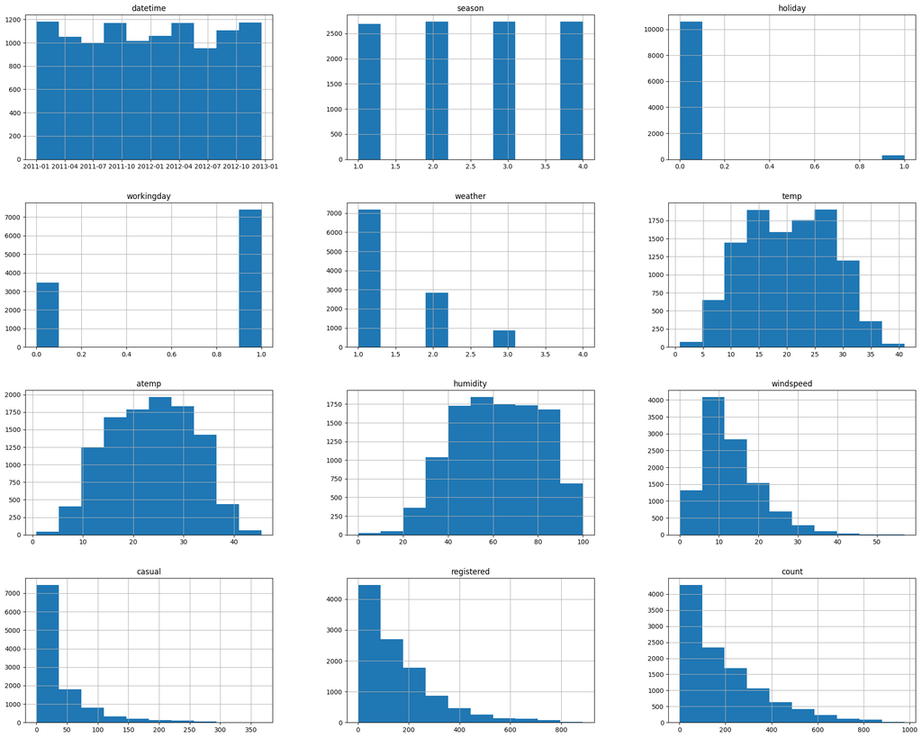

```python
# Create a histogram of all features to show the distribution of each one relative to the data. This is part of the exploritory data analysis
train.hist(figsize=(25,20));
```

```python
train.head()
```

|  | datetime | season | holiday | workingday | weather | temp | atemp | humidity | windspeed | casual | registered | count |
| --- | --- | --- | --- | --- | --- | --- | --- | --- | --- | --- | --- | --- |
| 0 | 2011-01-01 00:00:00 | 1 | 0 | 0 | 1 | 9.84 | 14.395 | 81 | 0.0 | 3 | 13 | 16 |
| 1 | 2011-01-01 01:00:00 | 1 | 0 | 0 | 1 | 9.02 | 13.635 | 80 | 0.0 | 8 | 32 | 40 |
| 2 | 2011-01-01 02:00:00 | 1 | 0 | 0 | 1 | 9.02 | 13.635 | 80 | 0.0 | 5 | 27 | 32 |
| 3 | 2011-01-01 03:00:00 | 1 | 0 | 0 | 1 | 9.84 | 14.395 | 75 | 0.0 | 3 | 10 | 13 |
| 4 | 2011-01-01 04:00:00 | 1 | 0 | 0 | 1 | 9.84 | 14.395 | 75 | 0.0 | 0 | 1 | 1 |

```python
# Engineering datetime feature
train["year"] = train["datetime"].dt.year
train["month"] = train["datetime"].dt.month
train["day"] = train["datetime"].dt.day
train["hour"] = train["datetime"].dt.hour

train.head()
```

|  | datetime | season | holiday | workingday | weather | temp | atemp | humidity | windspeed | casual | registered | count | year | month | day | hour |
| --- | --- | --- | --- | --- | --- | --- | --- | --- | --- | --- | --- | --- | --- | --- | --- | --- |
| 0 | 2011-01-01 00:00:00 | 1 | 0 | 0 | 1 | 9.84 | 14.395 | 81 | 0.0 | 3 | 13 | 16 | 2011 | 1 | 1 | 0 |
| 1 | 2011-01-01 01:00:00 | 1 | 0 | 0 | 1 | 9.02 | 13.635 | 80 | 0.0 | 8 | 32 | 40 | 2011 | 1 | 1 | 1 |
| 2 | 2011-01-01 02:00:00 | 1 | 0 | 0 | 1 | 9.02 | 13.635 | 80 | 0.0 | 5 | 27 | 32 | 2011 | 1 | 1 | 2 |
| 3 | 2011-01-01 03:00:00 | 1 | 0 | 0 | 1 | 9.84 | 14.395 | 75 | 0.0 | 3 | 10 | 13 | 2011 | 1 | 1 | 3 |
| 4 | 2011-01-01 04:00:00 | 1 | 0 | 0 | 1 | 9.84 | 14.395 | 75 | 0.0 | 0 | 1 | 1 | 2011 | 1 | 1 | 4 |

```python
# Checking year column content
train["year"].value_counts()
```

```
year
2012    5464
2011    5422
Name: count, dtype: int64
```

```python
# Engineering datetime feature
test["year"] = test["datetime"].dt.year
test["month"] = test["datetime"].dt.month
test["day"] = test["datetime"].dt.day
test["hour"] = test["datetime"].dt.hour

test.head()
```

|  | datetime | season | holiday | workingday | weather | temp | atemp | humidity | windspeed | year | month | day | hour |
| --- | --- | --- | --- | --- | --- | --- | --- | --- | --- | --- | --- | --- | --- |
| 0 | 2011-01-20 00:00:00 | 1 | 0 | 1 | 1 | 10.66 | 11.365 | 56 | 26.0027 | 2011 | 1 | 20 | 0 |
| 1 | 2011-01-20 01:00:00 | 1 | 0 | 1 | 1 | 10.66 | 13.635 | 56 | 0.0000 | 2011 | 1 | 20 | 1 |
| 2 | 2011-01-20 02:00:00 | 1 | 0 | 1 | 1 | 10.66 | 13.635 | 56 | 0.0000 | 2011 | 1 | 20 | 2 |
| 3 | 2011-01-20 03:00:00 | 1 | 0 | 1 | 1 | 10.66 | 12.880 | 56 | 11.0014 | 2011 | 1 | 20 | 3 |
| 4 | 2011-01-20 04:00:00 | 1 | 0 | 1 | 1 | 10.66 | 12.880 | 56 | 11.0014 | 2011 | 1 | 20 | 4 |

```python
train.info()
```

[output not shown]

## Make category types for these so models know they are not just numbers

- AutoGluon originally sees these as ints, but in reality they are int representations of a category.
- Setting the dtype to category will classify these as categories in AutoGluon.

```python
train["season"] = train["season"].astype("category")
train["weather"] = train["weather"].astype("category")
train["workingday"] = train["workingday"].astype("category")

train.info()
```

```
<class 'pandas.core.frame.DataFrame'>
RangeIndex: 10886 entries, 0 to 10885
Data columns (total 16 columns):
 #   Column      Non-Null Count  Dtype
---  ------      --------------  -----
 0   datetime    10886 non-null  datetime64[ns]
 1   season      10886 non-null  category
 2   holiday     10886 non-null  int64
 3   workingday  10886 non-null  category
 4   weather     10886 non-null  category
 5   temp        10886 non-null  float64
 6   atemp       10886 non-null  float64
 7   humidity    10886 non-null  int64
 8   windspeed   10886 non-null  float64
 9   casual      10886 non-null  int64
 10  registered  10886 non-null  int64
 11  count       10886 non-null  int64
 12  year        10886 non-null  int32
 13  month       10886 non-null  int32
 14  day         10886 non-null  int32
 15  hour        10886 non-null  int32
dtypes: category(3), datetime64[ns](1), float64(3), int32(4), int64(5)
memory usage: 968.1 KB
```

```python
train.head()
```

|  | datetime | season | holiday | workingday | weather | temp | atemp | humidity | windspeed | casual | registered | count | year | month | day | hour |
| --- | --- | --- | --- | --- | --- | --- | --- | --- | --- | --- | --- | --- | --- | --- | --- | --- |
| 0 | 2011-01-01 00:00:00 | 1 | 0 | 0 | 1 | 9.84 | 14.395 | 81 | 0.0 | 3 | 13 | 16 | 2011 | 1 | 1 | 0 |
| 1 | 2011-01-01 01:00:00 | 1 | 0 | 0 | 1 | 9.02 | 13.635 | 80 | 0.0 | 8 | 32 | 40 | 2011 | 1 | 1 | 1 |
| 2 | 2011-01-01 02:00:00 | 1 | 0 | 0 | 1 | 9.02 | 13.635 | 80 | 0.0 | 5 | 27 | 32 | 2011 | 1 | 1 | 2 |
| 3 | 2011-01-01 03:00:00 | 1 | 0 | 0 | 1 | 9.84 | 14.395 | 75 | 0.0 | 3 | 10 | 13 | 2011 | 1 | 1 | 3 |
| 4 | 2011-01-01 04:00:00 | 1 | 0 | 0 | 1 | 9.84 | 14.395 | 75 | 0.0 | 0 | 1 | 1 | 2011 | 1 | 1 | 4 |

```python
test["season"] = test["season"].astype("category")
test["weather"] = test["weather"].astype("category")
test["workingday"] = test["workingday"].astype("category")

test.info()
```

```
<class 'pandas.core.frame.DataFrame'>
RangeIndex: 6493 entries, 0 to 6492
Data columns (total 13 columns):
 #   Column      Non-Null Count  Dtype
---  ------      --------------  -----
 0   datetime    6493 non-null   datetime64[ns]
 1   season      6493 non-null   category
 2   holiday     6493 non-null   int64
 3   workingday  6493 non-null   category
 4   weather     6493 non-null   category
 5   temp        6493 non-null   float64
 6   atemp       6493 non-null   float64
 7   humidity    6493 non-null   int64
 8   windspeed   6493 non-null   float64
 9   year        6493 non-null   int32
 10  month       6493 non-null   int32
 11  day         6493 non-null   int32
 12  hour        6493 non-null   int32
dtypes: category(3), datetime64[ns](1), float64(3), int32(4), int64(2)
memory usage: 425.5 KB
```

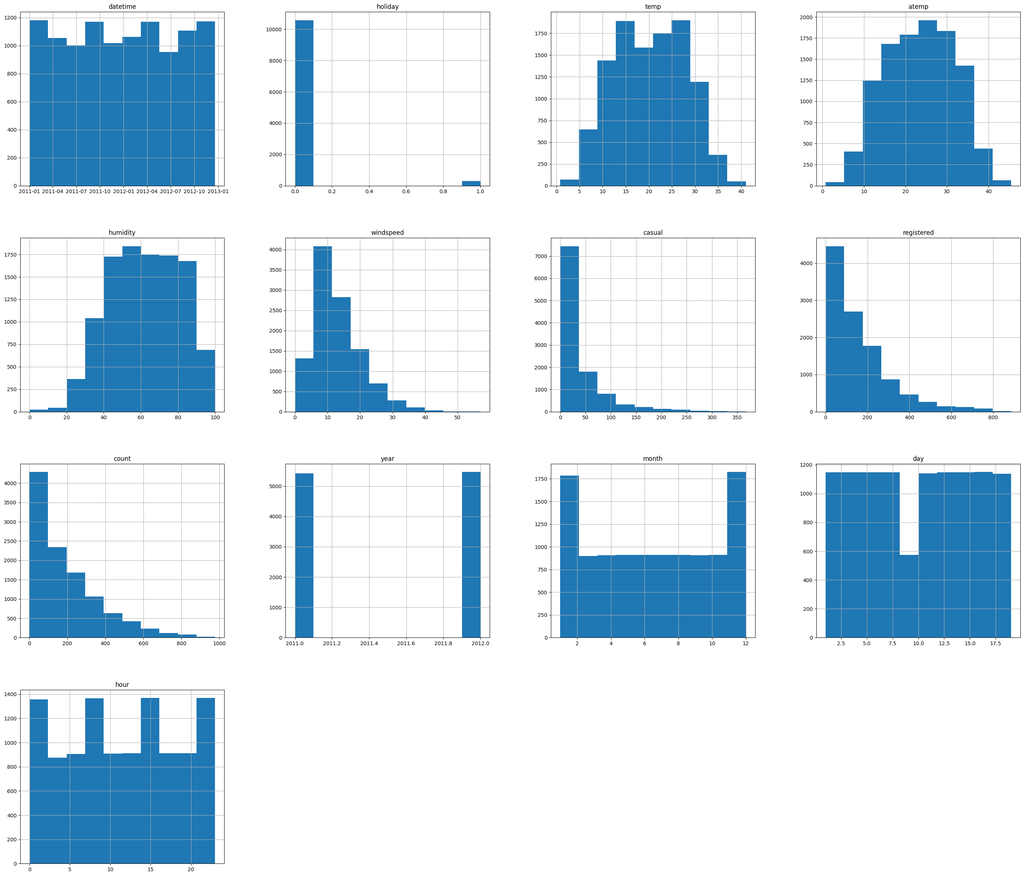

```python
# View histogram of all features again now with the hour feature
train.hist(figsize=(35,30));
```